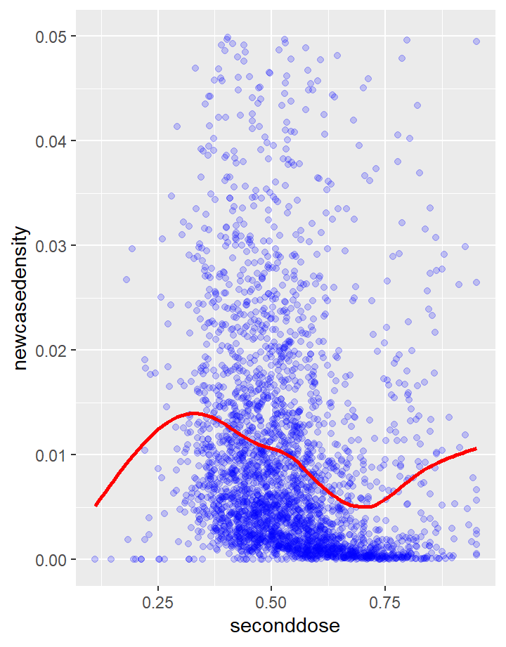

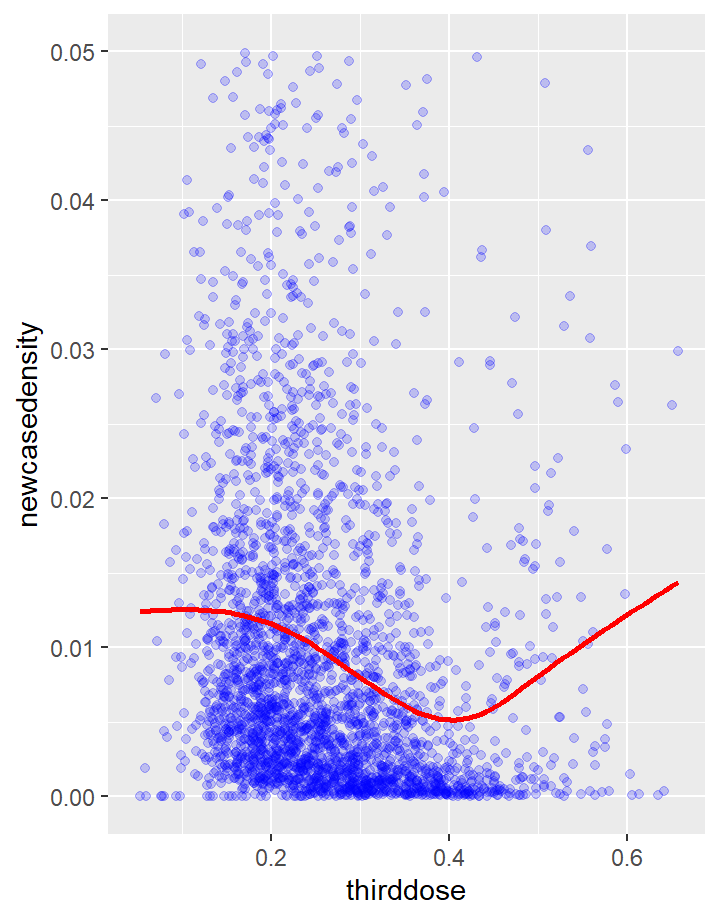

# Figures and Regressions

## Column {data-width = 450}

### Figure 1: Second-dose Completion Ratio and New Cases Per Capita

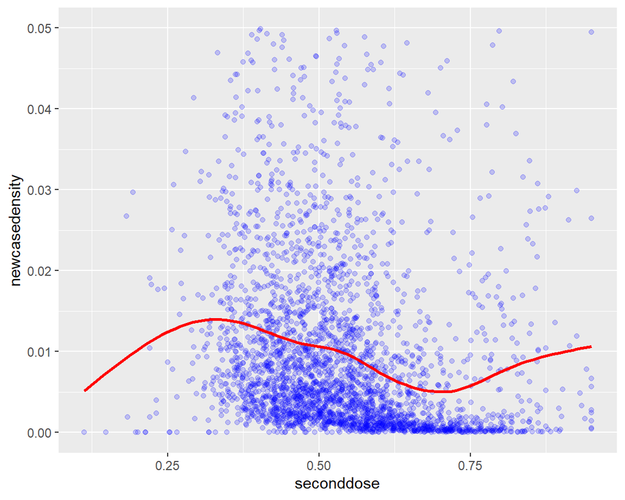

### Figure 2: Third-dose Completion Ratio and New Cases Per Capita

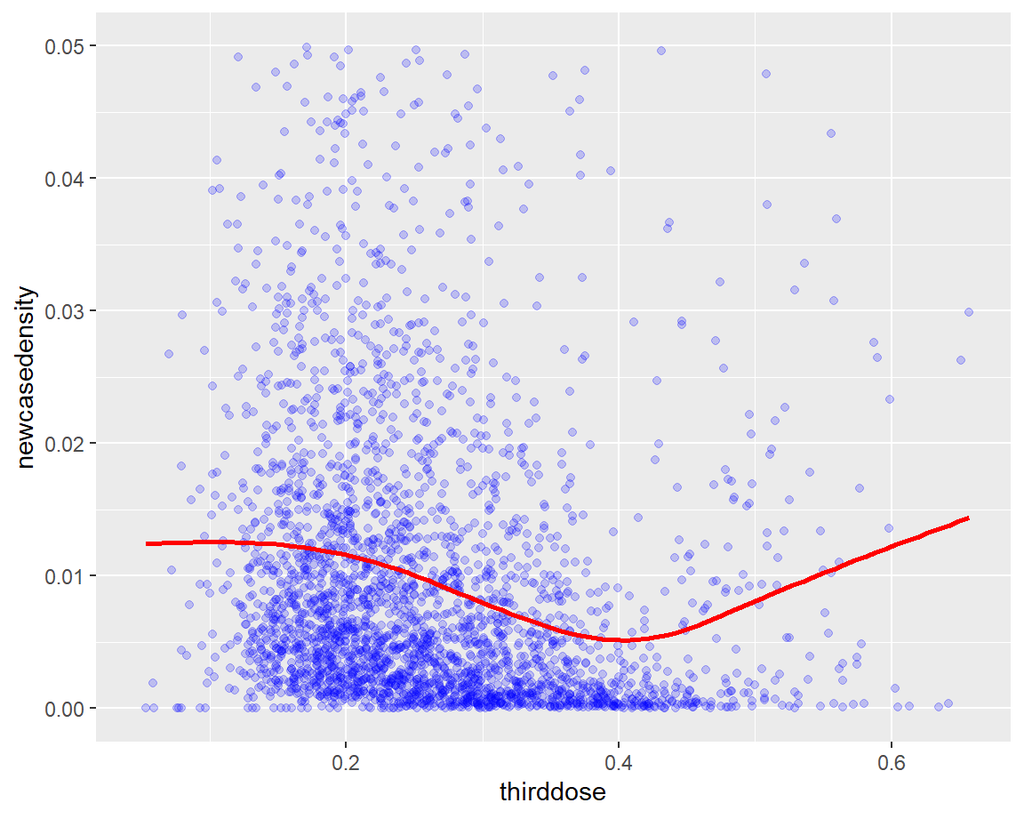

## Column {data-width = 250}

### About Figure 1

Several Observations have newcasedensity > 0.05. They are not shown in the Figure 1 to improve informativity.

### About Figure 2

Similarly,

Several Observations have newcasedensity > 0.05. They are not shown in the Figure 2 to improve informativity.

The fitted smooth line is a U-shaped curve. Therefore we add a quadratic term of thirddose to detect whether the U-shaped relationship is significant.

## Column {data-width = 450}

### Regression 1 - Second-dose Ratio

```
Call:
lm(formula = newcasedensity ~ seconddose2 + seconddose, data = df)

Residuals:
    Min      1Q  Median      3Q     Max
-0.4690 -0.0328  0.0042  0.0223 24.1686

Coefficients:
            Estimate Std. Error t value Pr(>|t|)
(Intercept)   0.7118     0.1040   6.847 9.03e-12 ***
seconddose2   1.9369     0.3260   5.942 3.13e-09 ***
seconddose   -2.3845     0.3739  -6.377 2.07e-10 ***
---
Signif. codes:  0 '***' 0.001 '**' 0.01 '*' 0.05 '.' 0.1 ' ' 1

Residual standard error: 0.4393 on 3123 degrees of freedom
  (97 observations deleted due to missingness)
Multiple R-squared:  0.01431,   Adjusted R-squared:  0.01368
F-statistic: 22.67 on 2 and 3123 DF,  p-value: 1.683e-10
```

### Regression 2 - Third-dose Ratio

```
Call:
lm(formula = newcasedensity ~ thirddose2 + thirddose, data = df)

Residuals:
    Min      1Q  Median      3Q     Max
-0.2304 -0.0370 -0.0013  0.0195 24.2857

Coefficients:
            Estimate Std. Error t value Pr(>|t|)
(Intercept)  0.30698    0.05626   5.456 5.26e-08 ***
thirddose2   2.79626    0.63069   4.434 9.60e-06 ***
thirddose   -1.91395    0.39233  -4.878 1.13e-06 ***
---
Signif. codes:  0 '***' 0.001 '**' 0.01 '*' 0.05 '.' 0.1 ' ' 1

Residual standard error: 0.4501 on 2992 degrees of freedom
  (228 observations deleted due to missingness)
Multiple R-squared:  0.00862,   Adjusted R-squared:  0.007957
F-statistic: 13.01 on 2 and 2992 DF,  p-value: 2.374e-06
```

# Explanation

Our regression models indicate that with the growing second dose vaccination completion ratio and third dose vaccination completion ratio, the new case density, which is (new cases) / (population), drops at the beginning, but rises up after reaching to a high level of the vaccination ratio (61.6% for second-dose, 34.3% for third-dose). All coefficients are significant at 1% level.

Such a trend can be explained through population density ratio, policy changes, and weaker policy implementation. Since our regressions are at the county level, there are many counties with a low population density ratio. In these counties, social distance can be naturally and more easily achieved in public area, thus a lower new case density. Futhermore, counties with high vaccination ratios tend to loose the covid safety restrctions, which leads a higher new case density. Similarly, residents in these counties also care relatively less if they strictly obligate the safety restrictions, and expose themselves to a higher infection risk.

Thankfully, recent variations of coronavirus are not likely to cause severe symtoms and death, so a sligtly higher new case density won’t be a serious problem.